# Kira Plastinina

#### Scatter Plots

Let’s plot some scatter plots to visualize the relationship between the numerical variables.

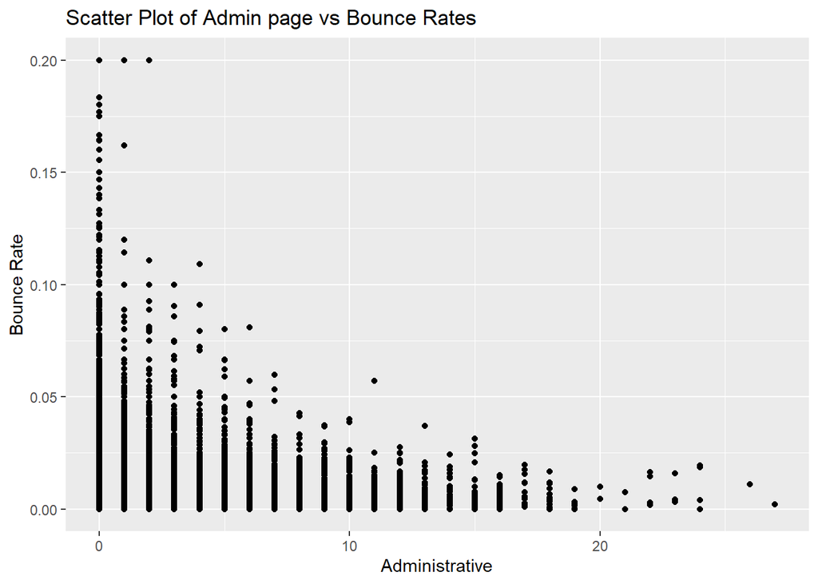

```r
ggplot(kira_p, aes(Administrative, BounceRates))+
  geom_point()+
  labs(title = "Scatter Plot of Admin page vs Bounce Rates",
       x = "Administrative",
       y = "Bounce Rate")
```

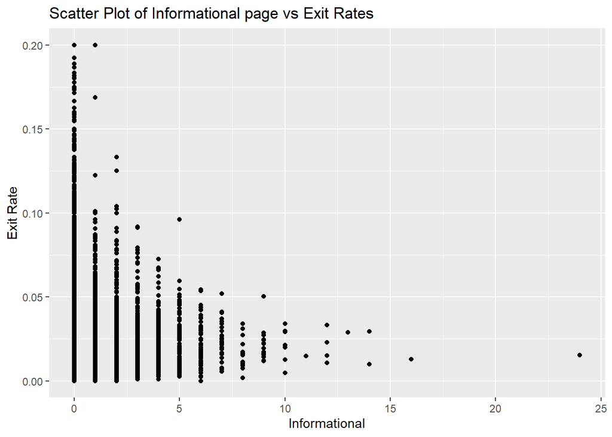

```r
ggplot(kira_p, aes(Informational, ExitRates))+
  geom_point()+
  labs(title = "Scatter Plot of Informational page vs Exit Rates",
       x = "Informational",
       y = "Exit Rate")
```

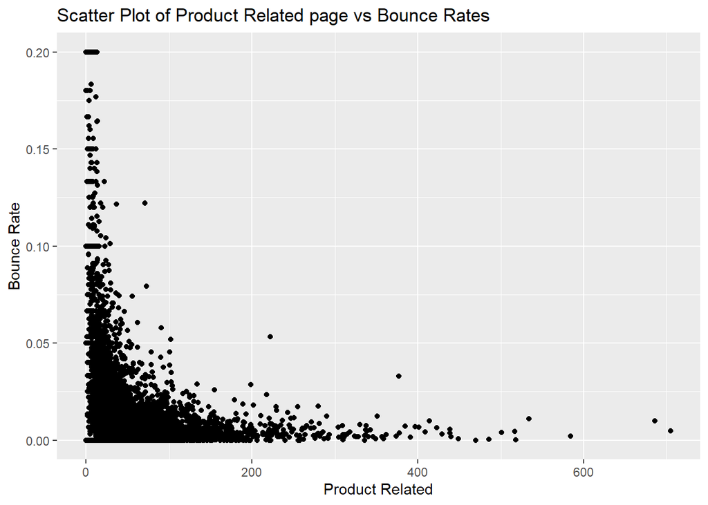

```r
ggplot(kira_p, aes(ProductRelated, BounceRates))+
  geom_point()+
  labs(title = "Scatter Plot of Product Related page vs Bounce Rates",
       x = "Product Related",
       y = "Bounce Rate")
```

## Modelling

### Unsupervised learning Techniques

#### K-Means Clustering

K-means clustering is a clustering algorithm that is commonly used for partitioning a given data set into a set of k groups (i.e. k clusters), where k represents the number of groups pre-specified. The algorithm tries to find groups by minimizing the distance between the observations, called local optimal solutions. The distances are measured based on the coordinates of the observations. Let’s implement this in our dataset. First we will process this data for modelling.

```r
library(plyr)

kira_p$Month <- factor(kira_p$Month, order = TRUE, levels =c('Feb', 'Mar', 'May', 'June','Jul', 'Aug', 'Sep','Oct', 'Nov','Dec'))
kira_p$Month_num <- mapvalues(kira_p$Month, from = c('Feb', 'Mar', 'May', 'June','Jul', 'Aug', 'Sep','Oct', 'Nov','Dec'), to = c(1,2,3,4,5,6,7,8,9,10))
kira_p$VisitorType <- factor(kira_p$VisitorType, order = TRUE, levels = c('Returning_Visitor', 'Other', 'New_Visitor'))
kira_p$VisitorType_Num <-mapvalues(kira_p$VisitorType, from = c("Returning_Visitor", "Other", "New_Visitor"), to = c(1,2,3))
kira_p$OperatingSystems <- factor(kira_p$OperatingSystems, order = TRUE, levels = c(6,3,7,1,5,2,4,8))
kira_p$Browser <- factor(kira_p$Browser, order = TRUE, levels = c(9,3,6,7,1,2,8,11,4,5,10,13,12))
kira_p$Region <- factor(kira_p$Region, order = TRUE, levels = c(8,6,3,4,7,1,5,2,9))
kira_p$TrafficType <- factor(kira_p$TrafficType, order = TRUE, levels = c(12,15,17,18,13,19,3,9,1,6,4,14,11,10,5,2,20,8,7,16))
kira_p$Weekend <- ifelse(kira_p$Weekend == TRUE, 1, 0)

str(kira_p)
```

```
## 'data.frame':    12199 obs. of  20 variables:
##  $ Administrative         : int  0 0 0 0 0 0 0 1 0 0 ...
##  $ Administrative_Duration: num  0 0 -1 0 0 0 -1 -1 0 0 ...
##  $ Informational          : int  0 0 0 0 0 0 0 0 0 0 ...
##  $ Informational_Duration : num  0 0 -1 0 0 0 -1 -1 0 0 ...
##  $ ProductRelated         : int  1 2 1 2 10 19 1 1 2 3 ...
##  $ ProductRelated_Duration: num  0 64 -1 2.67 627.5 ...
##  $ BounceRates            : num  0.2 0 0.2 0.05 0.02 ...
##  $ ExitRates              : num  0.2 0.1 0.2 0.14 0.05 ...
##  $ PageValues             : num  0 0 0 0 0 0 0 0 0 0 ...
##  $ SpecialDay             : num  0 0 0 0 0 0 0.4 0 0.8 0.4 ...
##  $ Month                  : Ord.factor w/ 10 levels "Feb"<"Mar"<"May"<..: 1 1 1 1 1 1 1 1 1 1 ...
##  $ OperatingSystems       : Ord.factor w/ 8 levels "6"<"3"<"7"<"1"<..: 4 6 7 2 2 6 6 4 6 6 ...
##  $ Browser                : Ord.factor w/ 13 levels "9"<"3"<"6"<"7"<..: 5 6 5 6 2 6 9 6 6 9 ...
##  $ Region                 : Ord.factor w/ 9 levels "8"<"6"<"3"<"4"<..: 6 6 9 8 6 6 3 6 8 6 ...
##  $ TrafficType            : Ord.factor w/ 20 levels "12"<"15"<"17"<..: 9 16 7 11 11 7 7 15 7 16 ...
##  $ VisitorType            : Ord.factor w/ 3 levels "Returning_Visitor"<..: 1 1 1 1 1 1 1 1 1 1 ...
##  $ Weekend                : num  0 0 0 0 0 0 0 0 0 0 ...
##  $ Revenue                : Factor w/ 2 levels "0","1": 1 1 1 1 1 1 1 1 1 1 ...
##  $ Month_num              : Ord.factor w/ 10 levels "1"<"2"<"3"<"4"<..: 1 1 1 1 1 1 1 1 1 1 ...
##  $ VisitorType_Num        : Ord.factor w/ 3 levels "1"<"2"<"3": 1 1 1 1 1 1 1 1 1 1 ...
##  - attr(*, "na.action")= 'omit' Named int [1:14] 1066 1133 1134 1135 1136 1137 1474 1475 1476 1477 ...
##   ..- attr(*, "names")= chr [1:14] "1066" "1133" "1134" "1135" ...
```

Since K Means is an unsupervised learning technique, we won’t require the Class label. We will therefore remove attribute, “Revenue” and store it in another variable.

```r
kira_p.new <- kira_p[,c(1,2,3,4,5,6,7,8,9)]
kira_p.class <- kira_p[, "Revenue"]

head(kira_p.new)
```

```
##   Administrative Administrative_Duration Informational Informational_Duration
## 1              0                       0             0                      0
## 2              0                       0             0                      0
## 3              0                      -1             0                     -1
## 4              0                       0             0                      0
## 5              0                       0             0                      0
## 6              0                       0             0                      0
##   ProductRelated ProductRelated_Duration BounceRates ExitRates PageValues
## 1              1                0.000000  0.20000000 0.2000000          0
## 2              2               64.000000  0.00000000 0.1000000          0
## 3              1               -1.000000  0.20000000 0.2000000          0
## 4              2                2.666667  0.05000000 0.1400000          0
## 5             10              627.500000  0.02000000 0.0500000          0
## 6             19              154.216667  0.01578947 0.0245614          0
```

Previewing our class column

```r
head(kira_p.class)
```

```
## [1] 0 0 0 0 0 0
## Levels: 0 1
```

```r
View(kira_p.new)
```

Normalizing the dataset so that no particular attribute has more impact on our algorithm than others.

```r
head(kira_p.new)
```

```
##   Administrative Administrative_Duration Informational Informational_Duration
## 1              0                       0             0                      0
## 2              0                       0             0                      0
## 3              0                      -1             0                     -1
## 4              0                       0             0                      0
## 5              0                       0             0                      0
## 6              0                       0             0                      0
##   ProductRelated ProductRelated_Duration BounceRates ExitRates PageValues
## 1              1                0.000000  0.20000000 0.2000000          0
## 2              2               64.000000  0.00000000 0.1000000          0
## 3              1               -1.000000  0.20000000 0.2000000          0
## 4              2                2.666667  0.05000000 0.1400000          0
## 5             10              627.500000  0.02000000 0.0500000          0
## 6             19              154.216667  0.01578947 0.0245614          0
```

```r
kira_p.new <- scale(kira_p.new)
head(kira_p.new)
```

```
##   Administrative Administrative_Duration Informational Informational_Duration
## 1     -0.7025315              -0.4601081    -0.3988128             -0.2462725
## 2     -0.7025315              -0.4601081    -0.3988128             -0.2462725
## 3     -0.7025315              -0.4657410    -0.3988128             -0.2533417
## 4     -0.7025315              -0.4601081    -0.3988128             -0.2462725
## 5     -0.7025315              -0.4601081    -0.3988128             -0.2462725
## 6     -0.7025315              -0.4601081    -0.3988128             -0.2462725
##   ProductRelated ProductRelated_Duration  BounceRates  ExitRates PageValues
## 1     -0.6963635              -0.6289343  3.954699721  3.4273070 -0.3190356
## 2     -0.6739424              -0.5955997 -0.450343788  1.2650121 -0.3190356
## 3     -0.6963635              -0.6294551  3.954699721  3.4273070 -0.3190356
## 4     -0.6739424              -0.6275453  0.650917089  2.1299300 -0.3190356
## 5     -0.4945739              -0.3020990 -0.009839437  0.1838646 -0.3190356
## 6     -0.2927843              -0.5486101 -0.102577188 -0.3661929 -0.3190356
```

Finding the optimal value of k

```r
# function to compute total within-cluster sum of square

library(purrr)
```

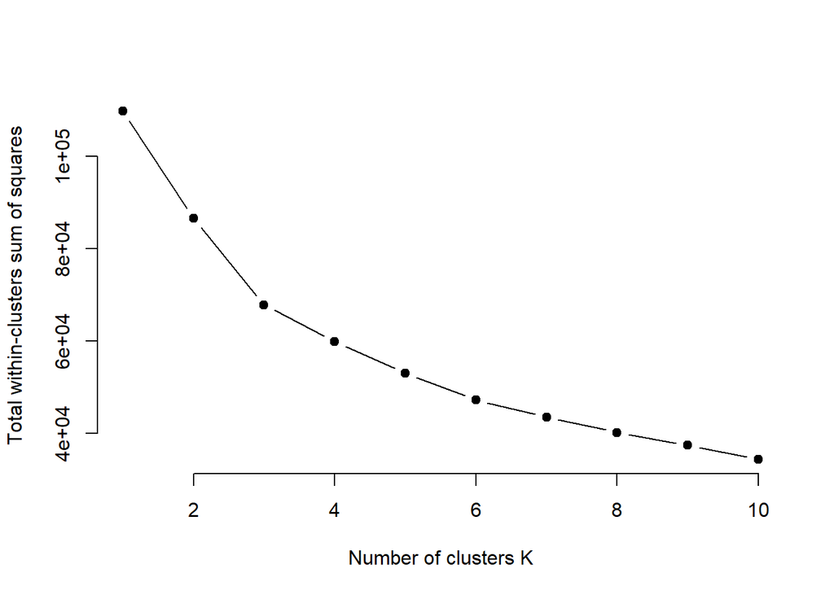

```r
wss <- function(k) {
  kmeans(kira_p.new, k, nstart = 10 )$tot.withinss
}

# Compute and plot wss for k = 1 to k = 15
k.values <- 1:10

# extract wss for 2-15 clusters
wss_values <- map_dbl(k.values, wss)
plot(k.values, wss_values,
       type="b", pch = 19, frame = FALSE,
       xlab="Number of clusters K",
       ylab="Total within-clusters sum of squares")
```

This gives us a k optimal value of 3. Applying the K-means clustering algorithm with 3 centroids.

```r
kmeansresult<- kmeans(kira_p.new,3)
```

Previewing the no of records in each cluster.

```r
kmeansresult$size
```

```
## [1] 1622  923 9654
```

Getting the value of cluster center datapoint value(3 center for k=3)

```r
kmeansresult$centers
```

```
##   Administrative Administrative_Duration Informational Informational_Duration
## 1      1.5137921               1.2759863     1.5771456              1.2587738
## 2     -0.6862680              -0.4511988    -0.3852256             -0.2458038
## 3     -0.1887244              -0.1712444    -0.2281507             -0.1879899
##   ProductRelated ProductRelated_Duration BounceRates  ExitRates  PageValues
## 1      1.4571509               1.3707331  -0.3125045 -0.4777569  0.19974221
## 2     -0.6469789              -0.5961841   3.1374102  2.9604080 -0.31903562
## 3     -0.1829643              -0.1733013  -0.2474567 -0.2027693 -0.00305697
```

Getting the cluster vector that shows where the cluster falls.

```r
kmeansresult$cluster
```

[output not shown]

[output cut: 1863 more lines]

Visualizing the clustering results.

```r
par(mfrow = c(1,2), mar = c(5,4,2,2))
```

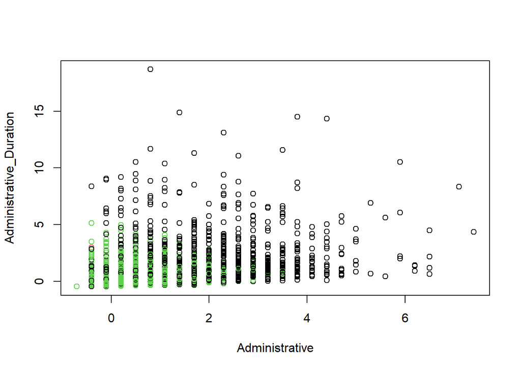

```r
plot(kira_p.new[,c(1,2)], col = kmeansresult$cluster)
```

Plotting to see how Page Related and Bounce points have been distributed in clusters.

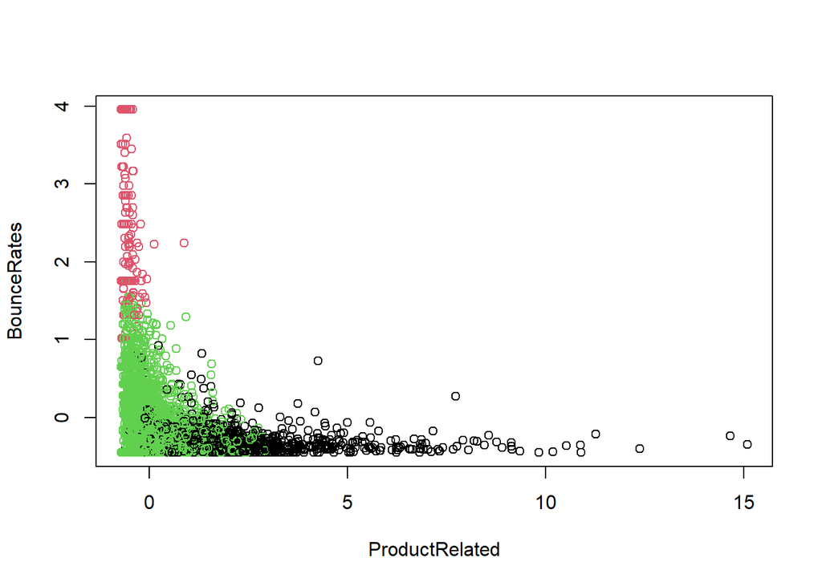

```r
plot(kira_p.new[,c(5,7)], col = kmeansresult$cluster)
```

Plotting to see how Informational and Exit Rates points have been distributed in clusters.

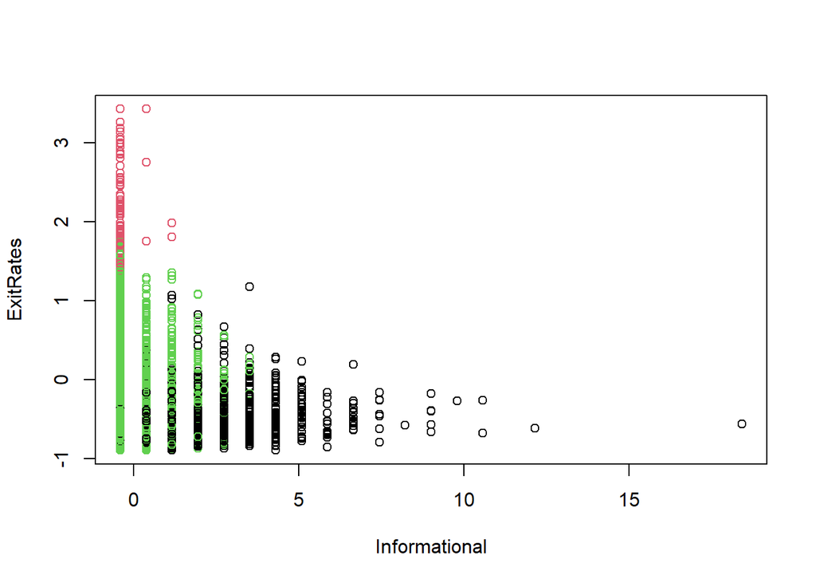

```r
plot(kira_p.new[,c(3,8)], col = kmeansresult$cluster)
```

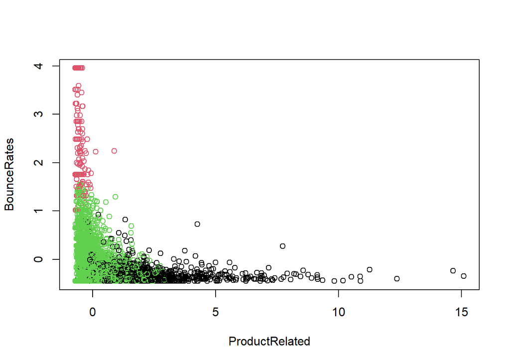

```r
plot(kira_p.new[,c(5,7)], col = kmeansresult$cluster)
```

[figure not shown]

```r
plot(kira_p.new[,c(5,7)], col = kira_p$class)
```

```r
table(kmeansresult$cluster, kira_p.class)
```

```
##    kira_p.class
##        0    1
##   1 1172  450
##   2  917    6
##   3 8202 1452
```

### Hierarchical Clustering

It’s an algorithm that groups similar objects in groups called clusters. It seeks to build a hierarchy of clusters. There are two types of hierarchical clustering;

- Agglomerative Clustering
- Divisive Clustering

We are going to implement the agglomerative clustering method. First we use the dist() function, to compute the euclidean distance between observations.

```r
d <- dist(kira_p.new, method = "euclidean")
```

We then perform hierarchical clustering using the Ward’s linkage method.

```r
res.hc <- hclust(d, method = "ward.D2" )
```

Let’s plot the dendrogram.

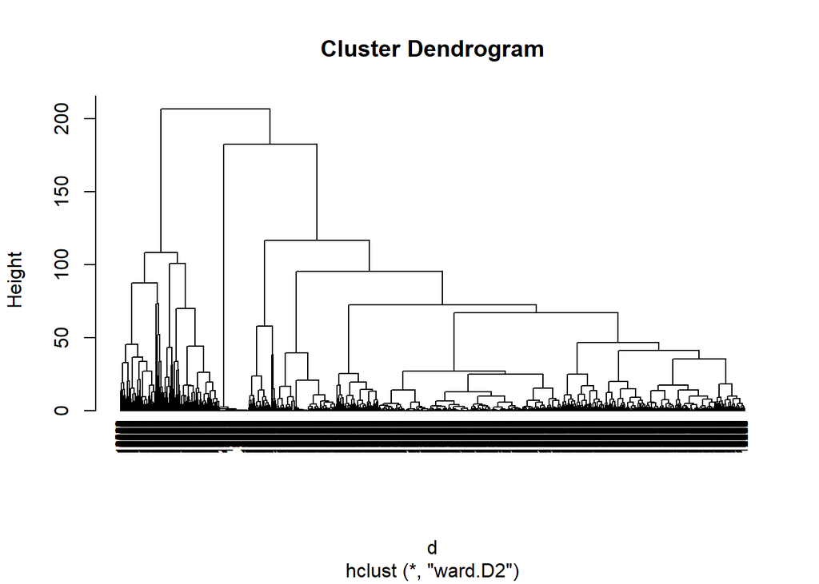

```r
plot(res.hc, cex = 0.6, hang = -1)
```

Using the complete method.

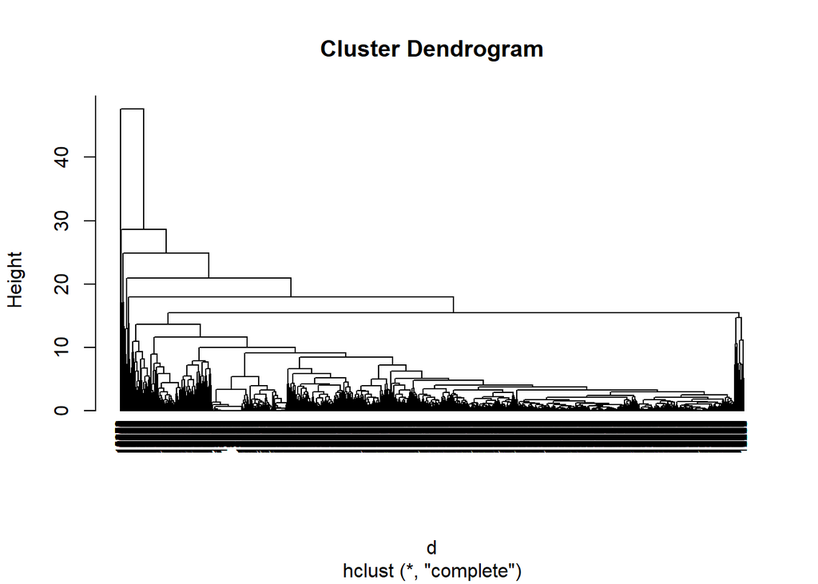

```r
res.hc <- hclust(d, method = "complete" )
plot(res.hc, cex = 0.6, hang = -1)
```

Using the single linkage method

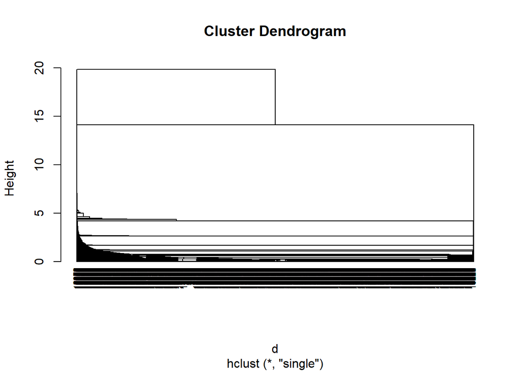

```r
res.hc <- hclust(d, method = "single" )
plot(res.hc, cex = 0.6, hang = -1)
```

Using the median linkage method.

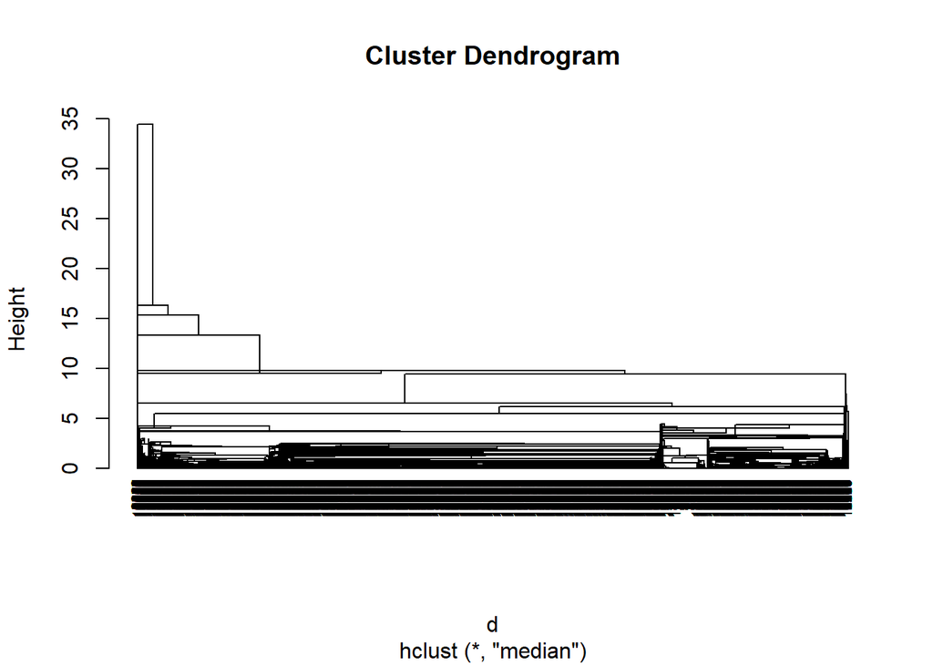

```r
res.hc <- hclust(d, method = "median" )
plot(res.hc, cex = 0.6, hang = -1)
```

## Comparison between the Kmeans and Hierarchical clustering

- Hierarchical clustering is good with small datasets compared to large ones like the one we have here. Therefore K means is a better algorithm for this kind of dataset and analysis.
- Hierarchical clustering requires high space and time complexity so it can’t be used when we have huge data like we do here.
- The only advantage Hierarchical clustering has over k means is that you don’t need to specify the number of clusters required for the algorithm in the beginning.
- K Means is an easy algorithm to implement compared to Hierarchical clustering. It’s only disadvantage is that it can be difficult to predict the number of clusters.

## Conclusions and Recommendations

- The client should use K Means to analyze this dataset since too big for hierarchical clustering, making it hard to get insights from the dendrograms.
- The client should ensure that the website’s interface is friendly for users.
- Optimization of the product pages by making the add cart option stand out, having short descriptions, using icons where needed, having a beautiful website that’s attractive to the eye and making sure that the shoppers experience is as smooth as possible.
- They could also engage the loyal customers in conversation by offering discounts for friends joining in.